# Grey Code Corporation Customer Renewal

```r
# This will delete everything in the global
# environment to get a 'clean slate' before
# executing anything.
rm(list = ls())
```

Grey Code Corporation (GCC) is a media and marketing company involved in magazine and book publishing and in television broadcasting. GCC’s portfolio of home and family magazines has been a long-running strength, but it has expanded to become a provider of a spectrum of services (market research, communications planning, web site advertising, etc.) that can enhance its clients’ brands.

GCC’s relational database contains over a terabyte of data encompassing 75 million customers. GCC uses the data in its database to develop campaigns for new customer acquisition, customer reactivation, and identification of cross-selling opportunities for products. For example, GCC will generate separate versions of a monthly issue of a magazine that will differ only by the advertisements they contain. It will mail a subscribing customer the version with the print ads identified by its database as being of most interest to that customer.

## TASKS

Construct a classification model to identify customers who are likely to respond to a maililng (`Renewal`) and document the following:

1. Explore the data, making sure to filter out unnecessary and redundant variables.
2. Experiment with various classification methods and propose a final model for identifying customers who will respond to the targeted marketing using proper evaluation methods, proper use of accuracy measures and visualizations with ROC curves and a Lift chart.
3. Include a recommendation for how to apply the results of your proposed model and how its use will affect GCC’s efforts at effective marketing - i.e., precision, sensitivity, and a lift chart. For example, if GCC sends the targeted marketing to the top 10% of the test set that the model believes is most likely to renew, what is the expected response rate? How does that compare to the industry’s average response rate?
4. Finally use XAI techniques to demonstrate the global behavior of your recommended model making sure to identify the most important features in your model and analyze their behavior using partial dependency plots.
5. Use XAI techinques to analyze and explain your model’s predictions for customers with ID numbers 12113, 9270, 12421. Make sure to identify and visualize the most important features for our model’s prediction on these specific customers, then analyze and visualize the behavior of those most important features for these customers. (You’ll use SHAP and Ceteris Paribus plots)

With 38 features, we should inspect and explore to make sure we don’t have unnecessary or redundant features that we can remove from the training. For example, the magazine does home and family type magazines and may be of interest to home owners. Several features measure aspects of home membership, possibly with redundance. The features `HomeOwner`, `DwellingType`,and `HomeValue` all touch upon the issue of living space and home ownership. For example, it may be the case that you can’t have a positive `HomeValue` if you do not own your home. Family structure is also repeatedly covered. `ChildPresent` is an indicator of children, and the three features `ChildX-X` are likelihoods of kids of a certain age in the home. Features like `Income` and `HomeValue` both touch upon a customer’s general affluence. Both could say different things, but perhaps not.

Several features touch upon customer behaviors. Some of these features may be calculated from others, like `DollarsPerIssue`.

```r
library(caret)
library(randomForest)
library(gbm)
library(DALEX)
library(pROC)
library(tidyverse)
library(performanceEstimation)
library(glmnet)
library(AppliedPredictiveModeling)
# Read in data, recode variable types, and
# change target to dummy var.
grey = read_csv("Grey.csv") %>%
  mutate_at(vars(DwellingType, Gender, Marital, ChildPresent,
                 Occupation, HomeValue, MagazineStatus, LastPaymentType,
                 GiftDonor), .funs = factor) %>%
  mutate(Renewal = factor(ifelse(Renewal=="Yes", 1, 0))) # make Renewal 0-1
```

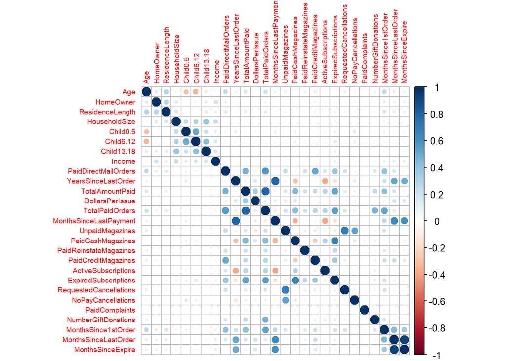

```r
# Look at a correlation plot to explore strong
# linear relationships between numeric predictors.
grey %>%
  select(-CustomerID) %>%
  keep(is.numeric) %>%
  cor() %>%
  corrplot::corrplot(tl.cex = 0.6)
```

Using the strong correlations above, we begin to see some possibly redundant numerical features. First, `TotalPaidOrders` and `TotalAmountPaid` are closely related but are at least different measures if the amount paid per order isn’t always the same. But if average amount per order is all that matters, then we might omit one. Second, `MonthsSinceLastPayment` and `YearsSinceLastOrder`. One is measured in years, the other months and assuming that last payments coincide most of the time with last order, these two essentially measure the same thing. Not surprisingly, `MonthsSinceLastOrder` is closely correlated with `YearsSinceLastOrder`. Also `MonthsSinceLastOrder` and `MonthsSinceLastPayment`, and also `MonthsSinceExpire` and `MonthsSinceLastOrder`. Another is `ExpiredSubscriptions` and `PaidCashMagazines`, but those may be truly different measures. `RequestedCancellations` and `UnpaidMagazines` are strongly similar, and make since that customers may have unpaid accounts for subscriptions they’re trying to cancel.

```r
set.seed(5832)
idx = sample(nrow(grey), 10000)
custs = grey[idx, ]
rm(idx)
```

```r
rf_model = readRDS("GCC_rf_model.rds")
custs$ProbRenewal = predict(rf_model, custs, type = "prob")[,"1"]
custs = custs %>%
select(ProbRenewal, Renewal)
head(custs)
```

```
## # A tibble: 6 x 2
##   ProbRenewal Renewal
##         <dbl> <fct>
## 1       0.18  0
## 2       0.146 0
## 3       0.96  0
## 4       0.136 0
## 5       0.09  0
## 6       0.26  0
```

```r
custs = custs %>%
arrange(desc(ProbRenewal)) %>%
mutate(CustCount = row_number()) %>%
select(CustCount, ProbRenewal, Renewal)
head(custs)
```

```
## # A tibble: 6 x 3
##   CustCount ProbRenewal Renewal
##       <int>       <dbl> <fct>
## 1         1       0.998 1
## 2         2       0.996 1
## 3         3       0.996 1
## 4         4       0.996 1
## 5         5       0.994 1
## 6         6       0.992 1
```

```r
# Create classification cutoff data
cut_offs = seq(0.01, 0.99, 0.01)
# Create blank dataframe to store values.
graph_data = data.frame(cutoff=NA, precision=NA,
recall=NA, accuracy=NA,
specificity=NA)
# Loop through cutoff values to
# calculate a confusion matrix and
# associated meaures for each cutoff.
for(c in cut_offs) {
class_label = factor(ifelse(custs$ProbRenewal > c, 1, 0), levels = c("0","1"))
cm = confusionMatrix(class_label, custs$Renewal, positive = "1")
graph_data = graph_data %>%
drop_na() %>%
add_row(cutoff = c,
precision = cm$byClass[["Pos Pred Value"]],
recall = cm$byClass[["Sensitivity"]],
accuracy = cm$overall[["Accuracy"]],
specificity = cm$byClass[["Specificity"]])
}
```

```r
custs = custs %>%
mutate(Renewal = as.numeric(levels(Renewal))[Renewal]) %>%
mutate(cumulative_renewals = cumsum(Renewal))
custs
```

```
## # A tibble: 10,000 x 4
##    CustCount ProbRenewal Renewal cumulative_renewals
##        <int>       <dbl>   <dbl>               <dbl>
##  1         1       0.998       1                   1
##  2         2       0.996       1                   2
##  3         3       0.996       1                   3
##  4         4       0.996       1                   4
##  5         5       0.994       1                   5
##  6         6       0.992       1                   6
##  7         7       0.992       1                   7
##  8         8       0.992       1                   8
##  9         9       0.992       1                   9
## 10        10       0.99        1                  10
## # i 9,990 more rows
```

```r
custs = custs %>%
mutate(percent_of_custs = CustCount/n()) %>%
mutate(percent_of_renewals = cumulative_renewals/sum(Renewal))
custs
```

```
## # A tibble: 10,000 x 6
##    CustCount ProbRenewal Renewal cumulative_renewals percent_of_custs
##        <int>       <dbl>   <dbl>               <dbl>            <dbl>
##  1         1       0.998       1                   1           0.0001
##  2         2       0.996       1                   2           0.0002
##  3         3       0.996       1                   3           0.0003
##  4         4       0.996       1                   4           0.0004
##  5         5       0.994       1                   5           0.0005
##  6         6       0.992       1                   6           0.0006
##  7         7       0.992       1                   7           0.0007
##  8         8       0.992       1                   8           0.0008
##  9         9       0.992       1                   9           0.0009
## 10        10       0.99        1                  10           0.001
## # i 9,990 more rows
## # i 1 more variable: percent_of_renewals <dbl>
```

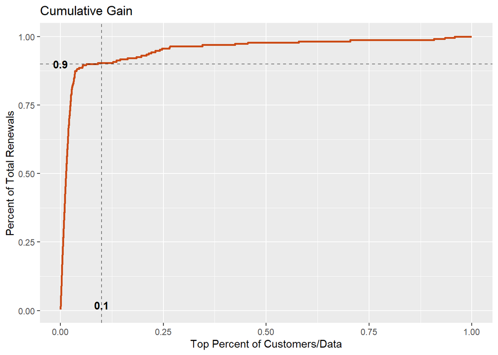

```r
custs %>%
ggplot(aes(x=percent_of_custs, y=percent_of_renewals)) +
geom_line(color = "#cb4b16", size = 1) +
geom_vline(xintercept = 0.1, linetype="dashed", alpha=0.5) +
annotate("text", x = 0.1, y=0.02, label = "0.1", fontface="bold") +
geom_hline(yintercept = 0.9, linetype="dashed", alpha=0.5) +
annotate("text", x = 0.0, y=0.9, label="0.9", fontface="bold") +
labs(title = "Cumulative Gain",
x = "Top Percent of Customers/Data",
y = "Percent of Total Renewals")
```

```r
4
```

```
## [1] 4
```

```r
custs = custs %>%
mutate(propRenew = cumulative_renewals / CustCount) %>%
mutate(baseline = sum(Renewal)/n()) %>%
mutate(lift = propRenew/baseline)
# View a subset of features to make it
# easier to see.
custs %>%select(percent_of_custs, percent_of_renewals, propRenew, baseline, lift)
```

```
## # A tibble: 10,000 x 5
##    percent_of_custs percent_of_renewals propRenew baseline  lift
##               <dbl>               <dbl>     <dbl>    <dbl> <dbl>
##  1           0.0001             0.00437         1   0.0229  43.7
##  2           0.0002             0.00873         1   0.0229  43.7
##  3           0.0003             0.0131          1   0.0229  43.7
##  4           0.0004             0.0175          1   0.0229  43.7
##  5           0.0005             0.0218          1   0.0229  43.7
##  6           0.0006             0.0262          1   0.0229  43.7
##  7           0.0007             0.0306          1   0.0229  43.7
##  8           0.0008             0.0349          1   0.0229  43.7
##  9           0.0009             0.0393          1   0.0229  43.7
## 10           0.001              0.0437          1   0.0229  43.7
## # i 9,990 more rows
```

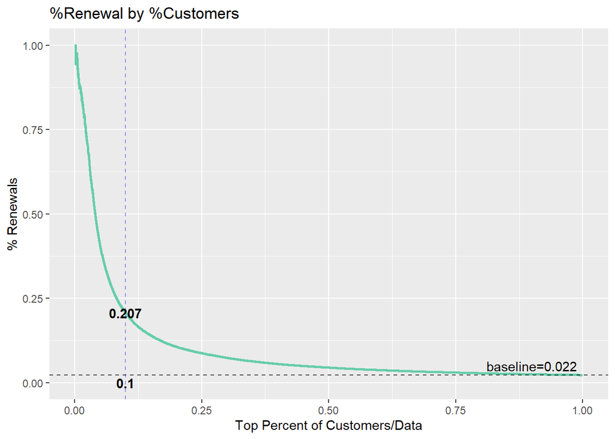

```r
ggplot(custs, aes(x=percent_of_custs, y=propRenew)) +
geom_line(color = "aquamarine3", size=1) +
geom_hline(yintercept = 0.022, linetype="dashed", alpha=0.7) +
geom_vline(xintercept = 0.1, linetype="dashed", color="blue", alpha=0.4) +
annotate("text", x=0.1, y=0.207, label="0.207", fontface="bold") +
annotate("text", x=0.1, y=0.0, label = "0.1", fontface="bold") +
annotate("text", x=0.9, y=0.05, label="baseline=0.022") +
labs(title="%Renewal by %Customers",
x = "Top Percent of Customers/Data",
y = "% Renewals")
```

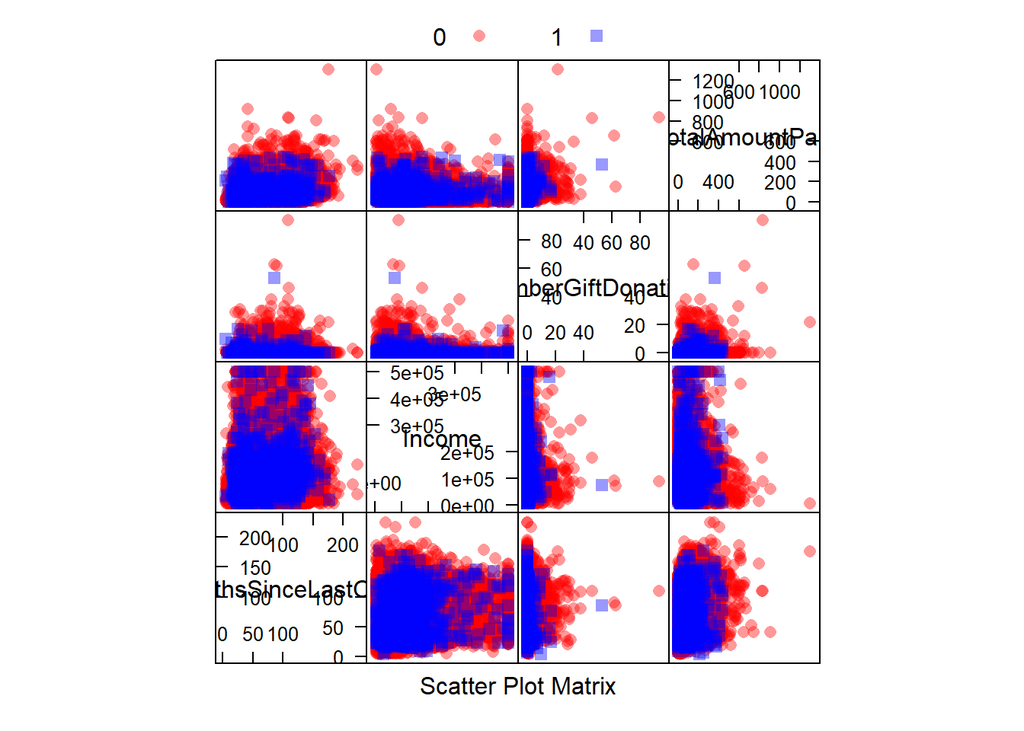

```r
# This sets a the based on the AppliedPredictiveModeling
# package. In particular, it controls transparency.
transparentTheme(trans = .4)
# The featurePlot will show scatterplots between our
# selected features and the target feature: Renewal
featurePlot(x = select(grey, MonthsSinceLastOrder, Income,
                       NumberGiftDonations, TotalAmountPaid),
            y = grey$Renewal,
            plot = "pairs",
            ## Add a key at the top
            auto.key = list(columns = 2))
```

```r
# Partition the data.
set.seed(596)
samp = createDataPartition(grey$Renewal,
                           p = 0.7,
                           list = FALSE)
train = grey[samp, ]
test = grey[-samp, ]
rm(samp)
```

```r
# Check for class imbalance problems.
train %>%
  select(Renewal) %>%
  table() %>% prop.table()
```

```
## .
##          0          1
## 0.97874724 0.02125276
```

From the above proportions table, we see that our renewal/response rate is barely over 2 percent! This is a very strong imbalance and we have relatively few cases of response/renewal to learn from.

```r
# Address the class imbalance problem
# using the SMOTE technique.
set.seed(4032)
train.bal = smote(Renewal ~ .,
                  data = train,
                  perc.over = 7,
                  perc.under = 1.5)

# After using SMOTE to balance training
# data, lets inspect the new counts.
train.bal %>%
  select(Renewal) %>%
  table()
```

```
## .
##    0    1
## 6573 5008
```

Now we can use the balanced training data to train our classifiers. Below is the code for both a random forest classifier, and a gradient boosting machine classifier. However, you’ll note that there is a large amount of commented-out code. The commented-out code is the actual code that was used to train the model and then save that model to a file (named `GCC_rf_model.rds` and `GCC_gbm_model.rd`). These files can then be reloaded. When model’s take a long time to train, and you have to write other parts of your document that are not changing that model, then this can help to reduce the need to re-train your model everytime you update something in the document. After saving model as a file, the model can be read in using the `readRDS()` function as you can see below.

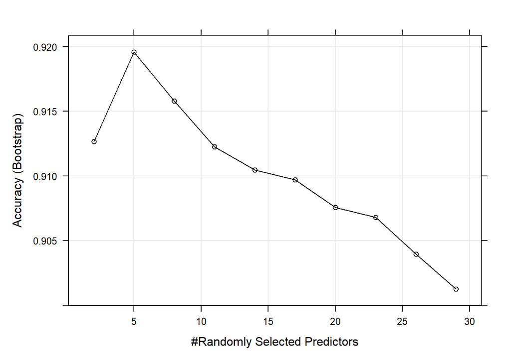

```r
# Train a random forest model
# set.seed(986)
# rf_model = train(
#   y = train.bal$Renewal,
#   x = select(train.bal, -CustomerID, -Renewal),
#   method = "rf",
#   trControl = trainControl(method = "boot", number = 30),
#   tuneLength = 10
# )
# saveRDS(rf_model, "GCC_rf_model.rds")
rf_model = readRDS("GCC_rf_model.rds")
plot(rf_model)
```

Our best model uses 5 predictors.

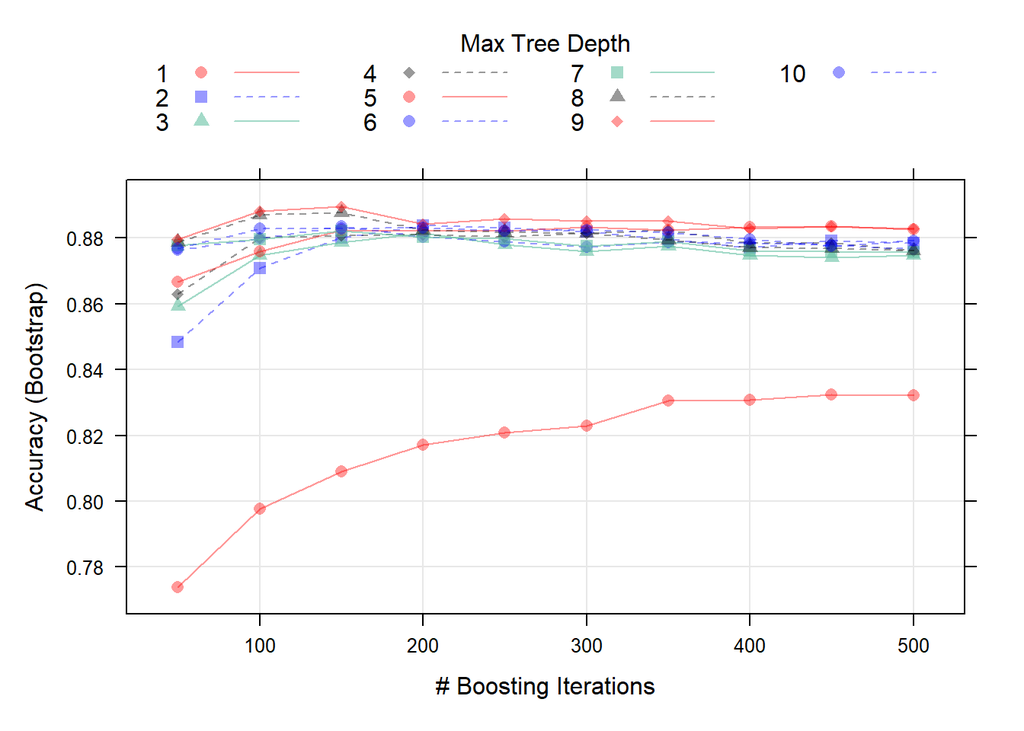

```r
# Train a gradient boost model
# set.seed(986)
# gbm_model = train(
#   y = train.bal$Renewal,
#   x = select(train.bal, -CustomerID, -Renewal),
#   method = "gbm",
#   verbose = FALSE,
#   trControl = trainControl(method = "boot", number = 5),
#   tuneLength = 10
# )
# saveRDS(gbm_model, "GCC_gbm_model.rds")
gbm_model = readRDS("GCC_gbm_model.rds")
plot(gbm_model)
```

Now that we have trained the models, we can create some “explainer” objects from the `DALEX` package which can be used to look at performance and to understand the model behavior.

```r
rf_explain = DALEX::explain(model = rf_model,
                            data = test,
                            y = as.numeric(test$Renewal=="1"),
                            type = "classification",
                            label = "Random Forest")
```

```
## Preparation of a new explainer is initiated
##   -> model label       :  Random Forest
##   -> data              :  12622  rows  38  cols
##   -> data              :  tibble converted into a data.frame
##   -> target variable   :  12622  values
##   -> predict function  :  yhat.train  will be used (  default  )
##   -> predicted values  :  No value for predict function target column. (  default  )
##   -> model_info        :  package caret , ver. 6.0.94 , task classification (  default  )
##   -> model_info        :  type set to  classification
##   -> predicted values  :  numerical, min =  0.01 , mean =  0.2307894 , max =  0.994
##   -> residual function :  difference between y and yhat (  default  )
##   -> residuals         :  numerical, min =  -0.99 , mean =  -0.2095566 , max =  0.942
##   A new explainer has been created!
```

```r
gbm_explain = DALEX::explain(model = gbm_model,
                             data = test,
                             y = as.numeric(test$Renewal=="1"),
                             type = "classification",
                             label = "GradientBoost")
```

```
## Preparation of a new explainer is initiated
##   -> model label       :  GradientBoost
##   -> data              :  12622  rows  38  cols
##   -> data              :  tibble converted into a data.frame
##   -> target variable   :  12622  values
##   -> predict function  :  yhat.train  will be used (  default  )
##   -> predicted values  :  No value for predict function target column. (  default  )
##   -> model_info        :  package caret , ver. 6.0.94 , task classification (  default  )
##   -> model_info        :  type set to  classification
##   -> predicted values  :  numerical, min =  0.004573958 , mean =  0.1627556 , max =  0.9915255
##   -> residual function :  difference between y and yhat (  default  )
##   -> residuals         :  numerical, min =  -0.9766621 , mean =  -0.1415228 , max =  0.9830515
##   A new explainer has been created!
```

```r
rf_perf = DALEX::model_performance(rf_explain, cutoff = 0.5)
rf_perf
```

```
## Measures for:  classification
## recall     : 0.6828358
## precision  : 0.2178571
## f1         : 0.3303249
## accuracy   : 0.9412138
## auc        : 0.871367
##
## Residuals:
##      0%     10%     20%     30%     40%     50%     60%     70%     80%     90%
## -0.9900 -0.4000 -0.3056 -0.2520 -0.2160 -0.1860 -0.1580 -0.1340 -0.1100 -0.0800
##    100%
##  0.9420
```

```r
gbm_perf = DALEX::model_performance(gbm_explain, cutoff = 0.5)
gbm_perf
```

```
## Measures for:  classification
## recall     : 0.7089552
## precision  : 0.1958763
## f1         : 0.3069467
## accuracy   : 0.9320235
## auc        : 0.8587623
##
## Residuals:
##          0%         10%         20%         30%         40%         50%
## -0.97666209 -0.35880864 -0.20779025 -0.14226122 -0.10797572 -0.08576398
##         60%         70%         80%         90%        100%
## -0.06819833 -0.05346748 -0.04076558 -0.02749358  0.98305147
```

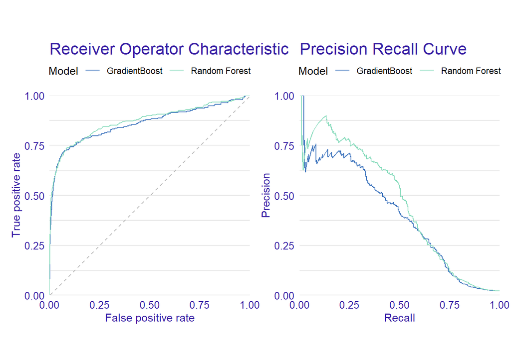

```r
library(patchwork)
p1 = plot(rf_perf, gbm_perf, geom = "roc")
p2 = plot(rf_perf, gbm_perf, geom = "prc")
p1 + p2
```

It looks like the light blue performs a bit better on both ROC and Precision Recall.

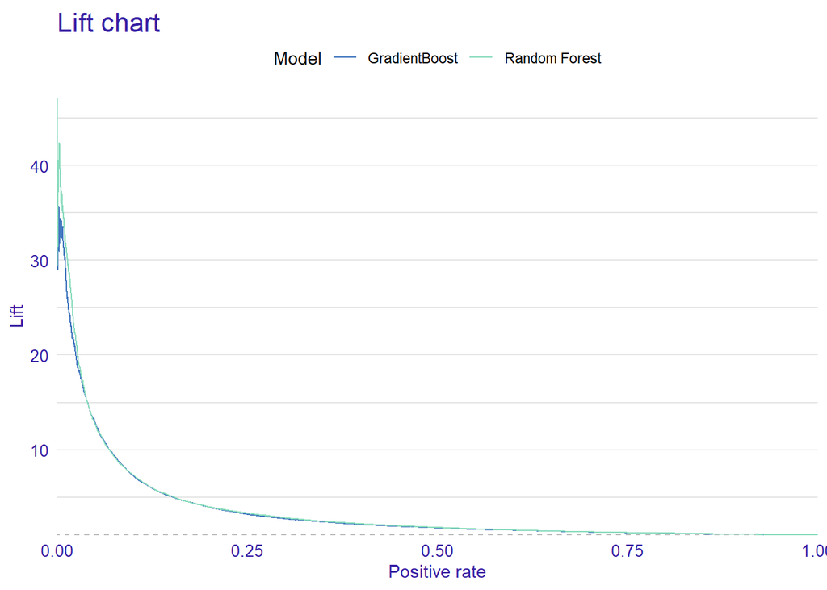

```r
#make gains
#look at code in there look for the top 10 percent
plot(rf_perf, gbm_perf, geom = "lift")
```

Random Forest Preforms better with Lift as well!

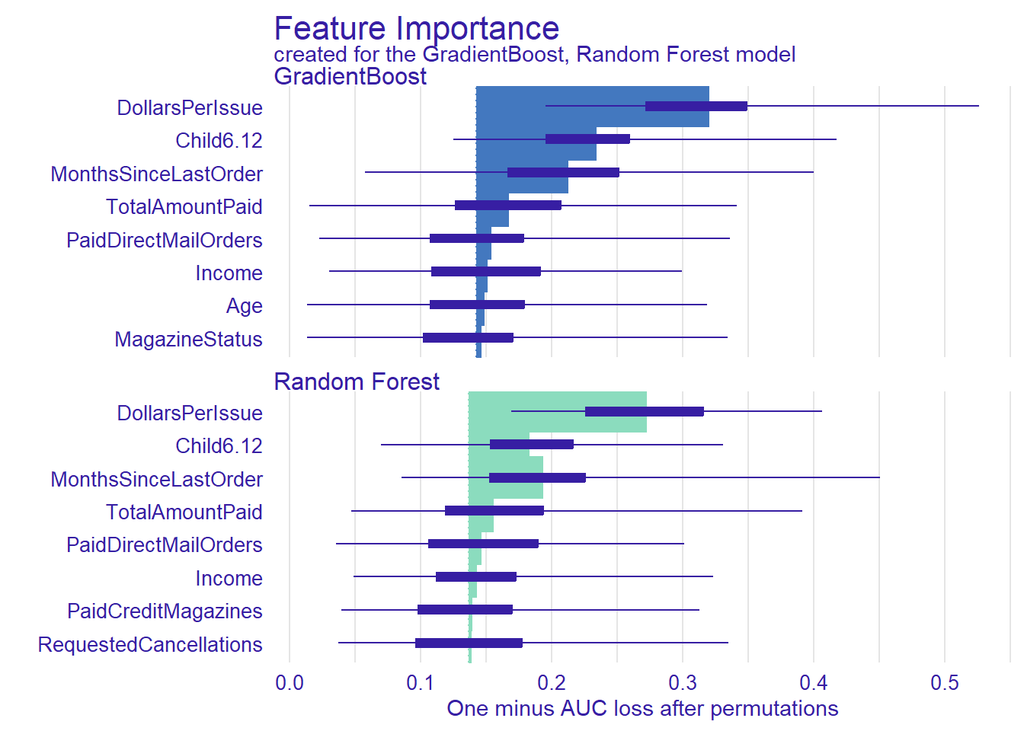

```r
rf_mp = DALEX::model_parts(rf_explain,
                           B = 50)

gbm_mp = DALEX::model_parts(gbm_explain,
                            B = 50)
plot(rf_mp, gbm_mp, max_vars = 8)
```

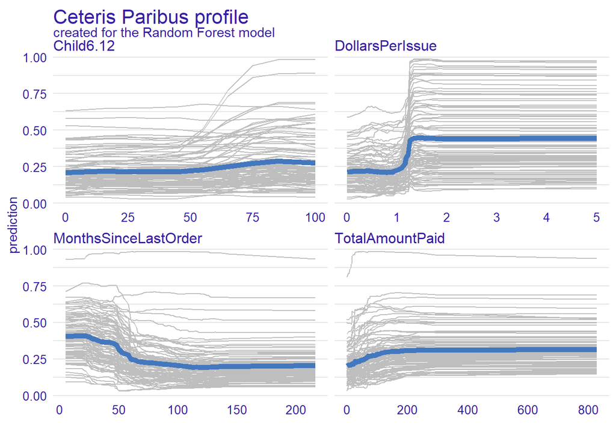

```r
rf_pp = DALEX::model_profile(rf_explain,
                             variables = c("DollarsPerIssue", "Child6.12",
                                           "MonthsSinceLastOrder", "TotalAmountPaid"),
                             N = 100)
gbm_pp = DALEX::model_profile(gbm_explain,
                             variables = c("DollarsPerIssue", "Child6.12",
                                           "MonthsSinceLastOrder", "TotalAmountPaid"),
                             N = 100)

plot(rf_pp, geom="profiles")
```

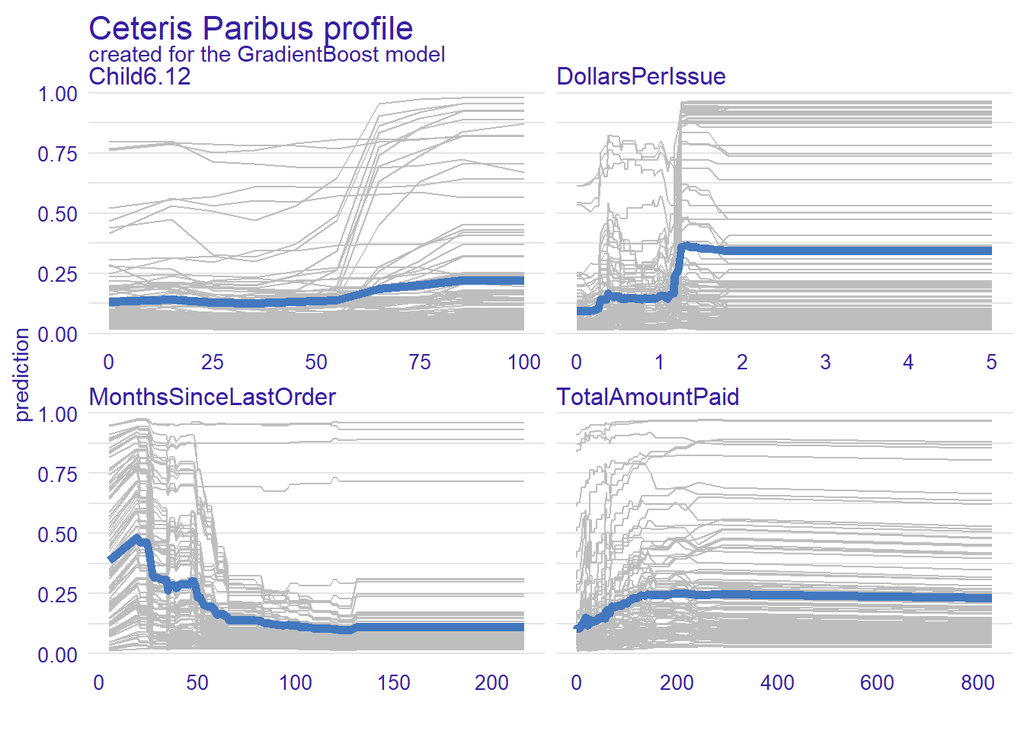

```r
plot(gbm_pp, geom="profiles")
```

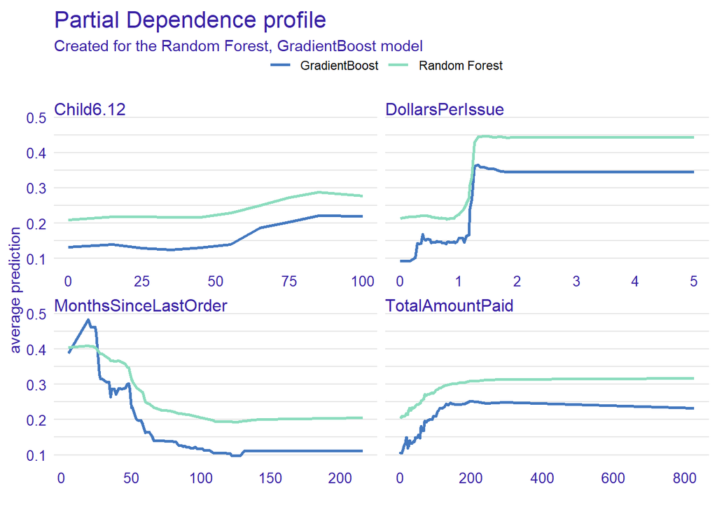

```r
plot(rf_pp, gbm_pp)
```